# Laboratorio: análisis exploratorio y comparación de dos señales

De la pregunta fisiológica a una comparación técnicamente válida

Autor/a

Ph.D. Pablo Eduardo Caicedo R.

Fecha de publicación

27 de septiembre de 2026

**ImportantePregunta rectora**

¿Qué características temporales, estadísticas y espectrales cambian entre dos registros del **mismo tipo de señal**, obtenidos en **dos contextos distintos**, y cuáles de esas diferencias pueden interpretarse desde la fisiología y el proceso de adquisición?

## 1 Información general

| Elemento | Descripción |
| --- | --- |
| Modalidad | Trabajo en grupos con sustentación |
| Duración sugerida | 6 horas: 1 h de diseño, 4 h de análisis y 1 h de síntesis |
| Lenguaje | Python 3.11 o superior |
| Producto | Archivo `.qmd`, HTML reproducible y sustentación breve |
| Datos | Una señal por contexto, con metadatos y procedencia verificable |
| Regla de comparación | Misma variable fisiológica, unidad, canal o localización anatómica comparable |

### 1.1 Resultados de aprendizaje

Al terminar el laboratorio, el estudiante podrá:

1. formular una pregunta comparativa que conecte señal, contexto y mecanismo fisiológico;
2. auditar la calidad y la comparabilidad de dos registros;
3. realizar análisis exploratorio en los dominios del tiempo y de la frecuencia;
4. seleccionar características coherentes con la señal elegida;
5. diferenciar una comparación descriptiva entre registros de una comparación punto a punto;
6. argumentar conclusiones sin confundir diferencias observadas con evidencia poblacional o clínica.

**NotaAlineación con la asignatura**

La práctica integra mediciones temporales, segmentación, normalización, interpretación biomédica, transformada discreta de Fourier, densidad espectral de potencia, método de Welch y señales no estacionarias. Estos contenidos corresponden a la Parte I del programa de **Sistemas y Señales Biomédicos** y a los capítulos 1, 2, 3 y 10 del texto guía de Semmlow.

## 2 1. Antes de programar: diseñar la comparación

### 2.1 1.1 Definir señal y contextos

Complete la siguiente ficha antes de abrir los archivos.

| Campo | Contexto A | Contexto B |
| --- | --- | --- |
| Tipo de señal |  |  |
| Fenómeno fisiológico |  |  |
| Contexto o condición |  |  |
| Participante / fuente |  |  |
| Canal y localización |  |  |
| Unidad de amplitud |  |  |
| Frecuencia de muestreo |  |  |
| Duración útil |  |  |
| Equipo / sensor |  |  |
| Preprocesamiento previo |  |  |

Escriba una pregunta con esta forma:

> ¿Cómo cambia **[característica medible]** de **[tipo de señal]** entre **[contexto A]** y **[contexto B]**, y qué mecanismo fisiológico o de adquisición podría explicar el cambio?

Formule además:

- una hipótesis fisiológica;
- una explicación alternativa asociada con sensor, protocolo, artefactos o procesamiento;
- una predicción observable en tiempo, amplitud o frecuencia.

### 2.2 1.2 Decidir qué significa “comparar”

| Situación | Pregunta válida | Herramientas principales |
| --- | --- | --- |
| Registros independientes | ¿Cambian sus distribuciones, descriptores o contenido espectral? | Resúmenes, ventanas, histogramas, PSD de Welch, características específicas |
| Registros simultáneos o alineables | ¿Qué tan similares son y existe retardo? | Correlación cruzada, error, coherencia, comparación morfológica |
| Mismo evento repetido | ¿Cambia la forma o amplitud del evento? | Detección, alineación por evento, promedio de ciclos y dispersión |

**AdvertenciaLímite de inferencia**

Con un único registro por contexto se describe **lo observado en esos dos registros**. Dividirlos en ventanas no crea participantes independientes: usar esas ventanas en una prueba de hipótesis como si fueran sujetos constituye **pseudorreplicación**. No se permiten afirmaciones de eficacia, diagnóstico ni generalización poblacional.

### 2.3 1.3 Criterios mínimos de comparabilidad

Antes de continuar, verifique:

- ambos archivos representan la misma magnitud fisiológica;
- las unidades son iguales o se conoce una conversión válida;
- canal, derivación, músculo, eje o localización son equivalentes;
- se conocen frecuencia de muestreo y duración;
- las condiciones de adquisición no introducen una confusión obvia;
- cualquier filtrado, rectificación o normalización previa está documentado;
- los registros tienen consentimiento/licencia y están anonimizados.

Si no se cumplen los tres primeros criterios, **no compare amplitudes directamente**.

## 3 2. Selección del análisis según la señal

No existe un EDA universal. La señal determina qué evento, banda, ventana y descriptor tienen sentido.

| Señal | Inspección temporal | Características posibles | Análisis frecuencial | Precaución principal |
| --- | --- | --- | --- | --- |
| ECG | línea base, complejos y artefactos | intervalos RR, frecuencia cardiaca, amplitud y duración de eventos | PSD de RR o segmentos; interferencia de red | no interpretar morfología sin derivación y calibración comparables |
| sEMG | reposo, ráfagas, saturación | RMS, MAV, iEMG, cruces por cero con umbral, duración de activación | frecuencia mediana y media, potencia por bandas | la amplitud depende de electrodo, músculo y contracción |
| EEG | deriva, parpadeos, actividad transitoria | media, varianza, RMS, entropía espectral | potencia absoluta/relativa por bandas | bandas y referencias deben justificarse; vigilar volumen conductor |
| PPG | pulsos, línea base, movimiento | intervalo entre pulsos, amplitud AC, variabilidad | tasa de pulso y modulación de baja frecuencia | contacto, perfusión y movimiento alteran la amplitud |
| Respiración | ciclos, apneas del registro, deriva | frecuencia respiratoria, amplitud, duración inspiratoria/espiratoria | pico respiratorio y variabilidad | sensor y posición modifican escala y forma |
| Acelerometría / marcha | impactos, ciclos y ejes | cadencia, intervalos de paso, RMS, magnitud vectorial | potencia de cadencia y armónicos | orientación, lado corporal y velocidad deben controlarse |

**Tarea 1.** Seleccione de tres a cinco características. Para cada una, escriba: definición, unidad, relación fisiológica, supuesto y posible factor de confusión.

## 4 3. Preparar el proyecto reproducible

Estructura sugerida:

```
comparacion-senales/
├── laboratorio_comparacion_senales.qmd
├── bioforja-laboratorios.scss
├── datos/
│   ├── contexto_A.csv
│   └── contexto_B.csv
├── resultados/
└── README.md
```

Con `uv`, un entorno mínimo puede crearse así:

```bash
uv init
uv add numpy pandas scipy matplotlib seaborn jupyter
uv run quarto preview laboratorio_comparacion_senales.qmd
```

Cada CSV debe contener, como mínimo, una columna de tiempo y una de amplitud:

```
tiempo,amplitud
0.000,0.014
0.004,0.018
0.008,0.011
```

**TipSi no existe columna de tiempo**

Puede reconstruirse como $t[n]=n/f_s$, pero el valor de $f_s$ debe proceder de los metadatos, no de una suposición visual.

## 5 4. Configuración del análisis

Modifique solamente este bloque al iniciar. El modo demostración genera señales matemáticas reproducibles para comprobar que el documento funciona; **no representa una bioseñal real ni puede usarse en el informe**.

**Mostrar/ocultar código**

```python
from pathlib import Path

import numpy as np
import pandas as pd
import matplotlib.pyplot as plt
import seaborn as sns
from scipy import signal, stats

sns.set_theme(style="whitegrid", context="notebook")
PALETA = {"Contexto A": "#278b8c", "Contexto B": "#e76f51"}
SEMILLA = 2027

MODO_DEMOSTRACION = True  # Cambiar a False para analizar los datos del grupo.

CONFIG = {
    "archivo_A": Path("datos/contexto_A.csv"),
    "archivo_B": Path("datos/contexto_B.csv"),
    "contexto_A": "Contexto A",
    "contexto_B": "Contexto B",
    "columna_tiempo": "tiempo",
    "columna_senal": "amplitud",
    "unidad": "u.a.",
    "fs_A": None,  # Hz; obligatorio si el archivo no tiene tiempo.
    "fs_B": None,
    "frecuencia_min": 0.0,  # Hz para gráficos de PSD.
    "frecuencia_max": 40.0,
    "ventana_s": 4.0,
    "solapamiento": 0.50,
}
```

## 6 5. Carga y auditoría de los datos

### 6.1 5.1 Funciones de carga

**Mostrar/ocultar código**

```python
def crear_demostracion(fs: float = 250.0, duracion_s: float = 60.0):
    """Genera dos señales matemáticas; no simula una fisiología específica."""
    rng = np.random.default_rng(SEMILLA)
    t = np.arange(0, duracion_s, 1 / fs)
    envolvente_A = 1.0 + 0.15 * np.sin(2 * np.pi * 0.08 * t)
    envolvente_B = 1.0 + 0.30 * np.sin(2 * np.pi * 0.05 * t)
    x_A = envolvente_A * (
        0.75 * np.sin(2 * np.pi * 8.0 * t)
        + 0.25 * np.sin(2 * np.pi * 18.0 * t + 0.3)
    ) + 0.18 * rng.standard_normal(t.size)
    x_B = envolvente_B * (
        0.55 * np.sin(2 * np.pi * 10.0 * t + 0.5)
        + 0.38 * np.sin(2 * np.pi * 22.0 * t)
    ) + 0.24 * rng.standard_normal(t.size)
    return (
        pd.DataFrame({"tiempo": t, "amplitud": x_A}),
        pd.DataFrame({"tiempo": t, "amplitud": x_B}),
    )


def cargar_csv(ruta: Path, col_t: str, col_x: str, fs_declarada=None):
    df = pd.read_csv(ruta)
    if col_x not in df.columns:
        raise ValueError(f"No existe la columna de señal '{col_x}' en {ruta}.")
    df[col_x] = pd.to_numeric(df[col_x], errors="coerce")

    if col_t in df.columns:
        df[col_t] = pd.to_numeric(df[col_t], errors="coerce")
    elif fs_declarada is not None and fs_declarada > 0:
        df[col_t] = np.arange(len(df), dtype=float) / float(fs_declarada)
    else:
        raise ValueError("Falta la columna de tiempo y no se declaró una fs válida.")

    return df[[col_t, col_x]].copy()


if MODO_DEMOSTRACION:
    A, B = crear_demostracion()
else:
    A = cargar_csv(
        CONFIG["archivo_A"], CONFIG["columna_tiempo"],
        CONFIG["columna_senal"], CONFIG["fs_A"]
    )
    B = cargar_csv(
        CONFIG["archivo_B"], CONFIG["columna_tiempo"],
        CONFIG["columna_senal"], CONFIG["fs_B"]
    )

A["contexto"] = CONFIG["contexto_A"]
B["contexto"] = CONFIG["contexto_B"]
```

### 6.2 5.2 Integridad, muestreo y valores faltantes

**Mostrar/ocultar código**

```python
def auditar(df: pd.DataFrame, nombre: str, col_t: str, col_x: str):
    t = df[col_t].to_numpy(dtype=float)
    x = df[col_x].to_numpy(dtype=float)
    validos = np.isfinite(t) & np.isfinite(x)
    dt = np.diff(t[np.isfinite(t)])
    dt_pos = dt[dt > 0]

    fs_est = 1 / np.median(dt_pos) if dt_pos.size else np.nan
    jitter = (
        100 * np.std(dt_pos, ddof=1) / np.mean(dt_pos)
        if dt_pos.size > 1 else np.nan
    )
    return {
        "contexto": nombre,
        "muestras": len(df),
        "faltantes_o_no_finitos": int((~validos).sum()),
        "tiempo_duplicado": int(pd.Series(t).duplicated().sum()),
        "tiempo_no_creciente": int(np.sum(dt <= 0)),
        "duracion_s": float(np.nanmax(t) - np.nanmin(t)),
        "fs_estimada_Hz": fs_est,
        "jitter_dt_pct": jitter,
        "min": float(np.nanmin(x)),
        "max": float(np.nanmax(x)),
    }


auditoria = pd.DataFrame([
    auditar(A, CONFIG["contexto_A"], CONFIG["columna_tiempo"], CONFIG["columna_senal"]),
    auditar(B, CONFIG["contexto_B"], CONFIG["columna_tiempo"], CONFIG["columna_senal"]),
])
auditoria.round(4)
```

|  | contexto | muestras | faltantes_o_no_finitos | tiempo_duplicado | tiempo_no_creciente | duracion_s | fs_estimada_Hz | jitter_dt_pct | min | max |
| --- | --- | --- | --- | --- | --- | --- | --- | --- | --- | --- |
| 0 | Contexto A | 15000 | 0 | 0 | 0 | 59.996 | 250.0 | 0.0 | -1.5417 | 1.6543 |
| 1 | Contexto B | 15000 | 0 | 0 | 0 | 59.996 | 250.0 | 0.0 | -2.0424 | 1.7351 |

Interprete la tabla. Un `jitter_dt_pct` alto indica muestreo irregular; en ese caso, la FFT o Welch estándar no deben aplicarse sin una estrategia explícita de remuestreo o un método para datos irregulares.

**Tarea 2.** Documente cualquier descarte, interpolación o corrección. Nunca elimine valores solo porque “se ven extraños”.

**Mostrar/ocultar código**

```python
def limpieza_minima(df, col_t, col_x):
    limpio = df[[col_t, col_x, "contexto"]].copy()
    limpio = limpio.replace([np.inf, -np.inf], np.nan).dropna()
    limpio = limpio.drop_duplicates(subset=col_t, keep="first")
    limpio = limpio.sort_values(col_t).reset_index(drop=True)
    if not limpio[col_t].is_monotonic_increasing:
        raise ValueError("El tiempo debe ser estrictamente creciente.")
    return limpio


A = limpieza_minima(A, CONFIG["columna_tiempo"], CONFIG["columna_senal"])
B = limpieza_minima(B, CONFIG["columna_tiempo"], CONFIG["columna_senal"])

fs_A = 1 / np.median(np.diff(A[CONFIG["columna_tiempo"]]))
fs_B = 1 / np.median(np.diff(B[CONFIG["columna_tiempo"]]))
print(f"fs estimada A: {fs_A:.3f} Hz | fs estimada B: {fs_B:.3f} Hz")
```

```
fs estimada A: 250.000 Hz | fs estimada B: 250.000 Hz
```

## 7 6. EDA en el dominio del tiempo

### 7.1 6.1 Primero: observar el registro completo

**Mostrar/ocultar código**

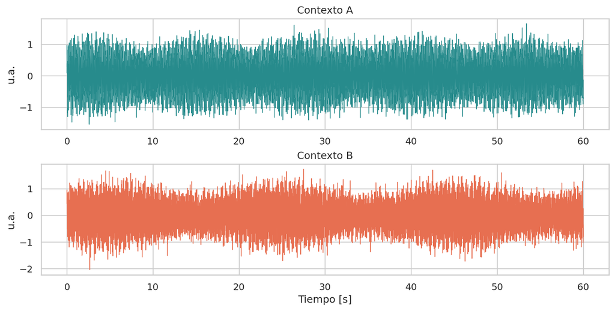

Registros completos. La superposición visual no implica comparabilidad punto a punto.

```python
fig, axes = plt.subplots(2, 1, sharex=False, figsize=(10, 5), constrained_layout=True)
for ax, df, nombre in zip(
    axes, [A, B], [CONFIG["contexto_A"], CONFIG["contexto_B"]]
):
    ax.plot(
        df[CONFIG["columna_tiempo"]], df[CONFIG["columna_senal"]],
        lw=0.8, color=PALETA[nombre]
    )
    ax.set(title=nombre, ylabel=CONFIG["unidad"])
axes[-1].set_xlabel("Tiempo [s]")
plt.show()
```

Busque: deriva, saturación, tramos planos, impulsos, cambios de varianza, eventos, transitorios y diferencias de duración.

### 7.2 6.2 Distribución y estadística robusta

Para una señal $x[n]$ de $N$ muestras:

$$\bar{x}=\frac{1}{N}\sum_{n=0}^{N-1}x[n], \qquad
x_{\mathrm{RMS}}=\sqrt{\frac{1}{N}\sum_{n=0}^{N-1}x^2[n]}.$$

La mediana y el rango intercuartílico (IQR) son menos sensibles a artefactos extremos que la media y la desviación estándar.

**Mostrar/ocultar código**

```python
def resumen_temporal(df, nombre, col_x):
    x = df[col_x].to_numpy(dtype=float)
    q1, mediana, q3 = np.quantile(x, [0.25, 0.50, 0.75])
    return {
        "contexto": nombre,
        "media": np.mean(x),
        "mediana": mediana,
        "desv_est": np.std(x, ddof=1),
        "IQR": q3 - q1,
        "RMS": np.sqrt(np.mean(x**2)),
        "MAV": np.mean(np.abs(x)),
        "asimetria": stats.skew(x, bias=False),
        "curtosis_exceso": stats.kurtosis(x, fisher=True, bias=False),
    }


resumen = pd.DataFrame([
    resumen_temporal(A, CONFIG["contexto_A"], CONFIG["columna_senal"]),
    resumen_temporal(B, CONFIG["contexto_B"], CONFIG["columna_senal"]),
]).set_index("contexto")
resumen.round(4)
```

| contexto | media | mediana | desv_est | IQR | RMS | MAV | asimetria | curtosis_exceso |
| --- | --- | --- | --- | --- | --- | --- | --- | --- |
| Contexto A | 0.0021 | -0.0021 | 0.5898 | 0.9727 | 0.5898 | 0.5057 | 0.0048 | -0.9564 |
| Contexto B | 0.0013 | 0.0050 | 0.5396 | 0.7480 | 0.5396 | 0.4362 | -0.0297 | -0.3099 |

**Mostrar/ocultar código**

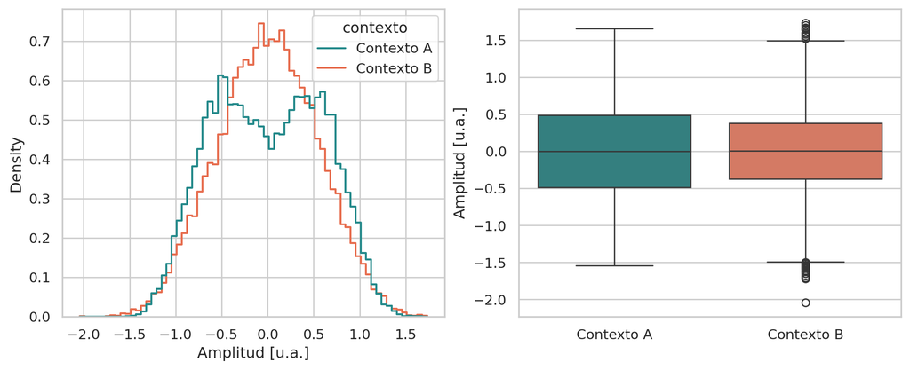

Distribuciones de amplitud. La forma depende del fenómeno, del ruido y del preprocesamiento.

```python
datos_largos = pd.concat([A, B], ignore_index=True)
fig, axes = plt.subplots(1, 2, figsize=(10, 4), constrained_layout=True)
sns.histplot(
    data=datos_largos, x=CONFIG["columna_senal"], hue="contexto",
    stat="density", common_norm=False, element="step", fill=False,
    palette=PALETA, ax=axes[0]
)
sns.boxplot(
    data=datos_largos, x="contexto", y=CONFIG["columna_senal"],
    hue="contexto", palette=PALETA, legend=False, ax=axes[1]
)
axes[0].set_xlabel(f"Amplitud [{CONFIG['unidad']}]")
axes[1].set(xlabel="", ylabel=f"Amplitud [{CONFIG['unidad']}]")
plt.show()
```

**AdvertenciaNormalizar no siempre es corregir**

Estandarizar cada registro por separado elimina diferencias de media y escala. Es útil para comparar **forma**, pero invalida una pregunta sobre diferencias de amplitud. Conserve siempre la señal en unidades físicas y justifique cualquier versión normalizada.

### 7.3 6.3 Artefactos candidatos, no “datos malos” automáticos

El puntaje robusto

$$z_r[n]=0.6745\,\frac{x[n]-\operatorname{mediana}(x)}{\operatorname{MAD}(x)}$$

sirve para **marcar candidatos** extremos. No prueba que una muestra sea artefacto.

**Mostrar/ocultar código**

```python
def mascara_extremos_robusta(x, umbral=6.0):
    x = np.asarray(x, dtype=float)
    med = np.median(x)
    mad = np.median(np.abs(x - med))
    if mad == 0:
        return np.zeros(x.shape, dtype=bool)
    z_robusto = 0.6745 * (x - med) / mad
    return np.abs(z_robusto) > umbral


for df, nombre in [(A, CONFIG["contexto_A"]), (B, CONFIG["contexto_B"])]:
    m = mascara_extremos_robusta(df[CONFIG["columna_senal"]])
    print(f"{nombre}: {m.sum()} candidatos ({100*m.mean():.3f} %)")
```

```
Contexto A: 0 candidatos (0.000 %)
Contexto B: 0 candidatos (0.000 %)
```

### 7.4 6.4 Variación temporal y estacionariedad local

Una señal débilmente estacionaria mantiene aproximadamente constantes su media y autocovarianza. En bioseñales es frecuente trabajar con segmentos **localmente estacionarios**.

**Mostrar/ocultar código**

```python
def extraer_ventanas(x, fs, duracion_s, solapamiento=0.5):
    x = np.asarray(x, dtype=float)
    n = max(8, int(round(duracion_s * fs)))
    paso = max(1, int(round(n * (1 - solapamiento))))
    if len(x) < n:
        raise ValueError("El registro es más corto que la ventana seleccionada.")
    inicios = np.arange(0, len(x) - n + 1, paso)
    return np.stack([x[i:i+n] for i in inicios]), inicios


def rasgos_genericos_por_ventana(df, nombre, fs, col_x, ventana_s, solapamiento):
    ventanas, inicios = extraer_ventanas(
        df[col_x].to_numpy(), fs, ventana_s, solapamiento
    )
    return pd.DataFrame({
        "contexto": nombre,
        "tiempo_centro_s": (inicios + ventanas.shape[1] / 2) / fs,
        "media": ventanas.mean(axis=1),
        "desv_est": ventanas.std(axis=1, ddof=1),
        "RMS": np.sqrt(np.mean(ventanas**2, axis=1)),
        "MAV": np.mean(np.abs(ventanas), axis=1),
    })


rasgos_A = rasgos_genericos_por_ventana(
    A, CONFIG["contexto_A"], fs_A, CONFIG["columna_senal"],
    CONFIG["ventana_s"], CONFIG["solapamiento"]
)
rasgos_B = rasgos_genericos_por_ventana(
    B, CONFIG["contexto_B"], fs_B, CONFIG["columna_senal"],
    CONFIG["ventana_s"], CONFIG["solapamiento"]
)
rasgos_ventanas = pd.concat([rasgos_A, rasgos_B], ignore_index=True)
```

**Mostrar/ocultar código**

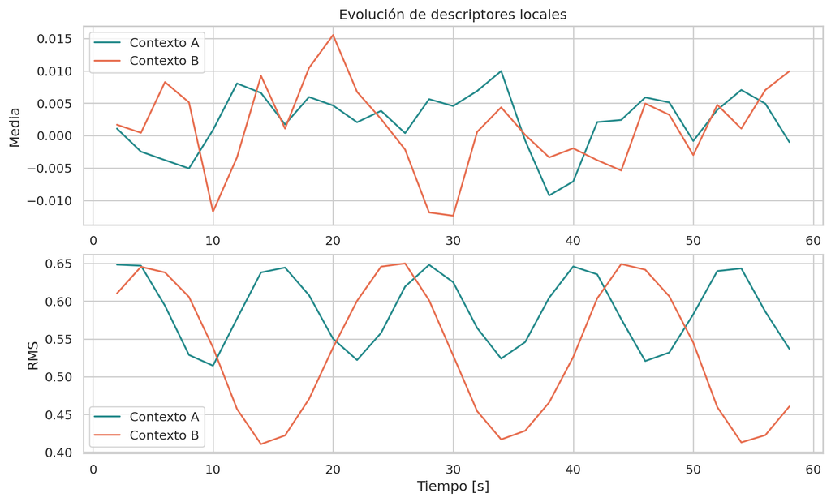

Media y RMS por ventana. Cambios sistemáticos sugieren no estacionariedad local.

```python
fig, axes = plt.subplots(2, 1, figsize=(10, 6), sharex=False, constrained_layout=True)
for contexto, grupo in rasgos_ventanas.groupby("contexto"):
    axes[0].plot(grupo["tiempo_centro_s"], grupo["media"],
                 label=contexto, color=PALETA[contexto])
    axes[1].plot(grupo["tiempo_centro_s"], grupo["RMS"],
                 label=contexto, color=PALETA[contexto])
axes[0].set(ylabel="Media", title="Evolución de descriptores locales")
axes[1].set(xlabel="Tiempo [s]", ylabel="RMS")
for ax in axes:
    ax.legend()
plt.show()
```

**Tarea 3.** Justifique el tamaño y el solapamiento de la ventana mediante el compromiso entre resolución temporal, estabilidad del estimador y fenómeno fisiológico. No copie `4 s` sin argumentarlo.

## 8 7. EDA en el dominio de la frecuencia

### 8.1 7.1 Densidad espectral de potencia mediante Welch

Welch divide el registro en segmentos, calcula periodogramas modificados y los promedia. El tamaño de segmento determina la resolución aproximada $\Delta f=f_s/N_{\text{seg}}$.

**Mostrar/ocultar código**

```python
def calcular_psd(x, fs, duracion_segmento_s=4.0, solapamiento=0.5):
    x = np.asarray(x, dtype=float)
    nperseg = min(len(x), max(16, int(round(duracion_segmento_s * fs))))
    noverlap = int(round(nperseg * solapamiento))
    f, pxx = signal.welch(
        x, fs=fs, window="hann", nperseg=nperseg,
        noverlap=noverlap, detrend="constant", scaling="density"
    )
    return f, pxx


f_A, P_A = calcular_psd(
    A[CONFIG["columna_senal"]], fs_A,
    CONFIG["ventana_s"], CONFIG["solapamiento"]
)
f_B, P_B = calcular_psd(
    B[CONFIG["columna_senal"]], fs_B,
    CONFIG["ventana_s"], CONFIG["solapamiento"]
)
```

**Mostrar/ocultar código**

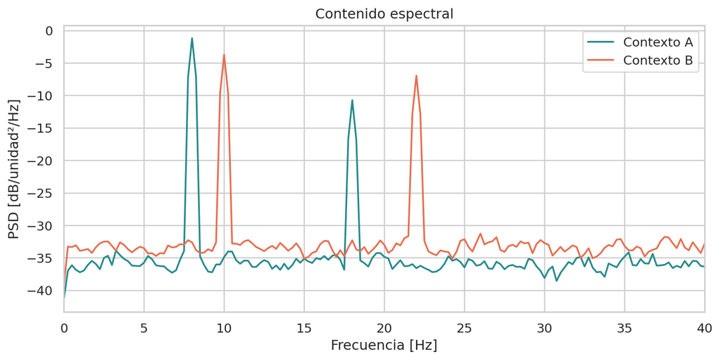

PSD de Welch. Deben compararse sobre el mismo intervalo de frecuencias.

```python
fig, ax = plt.subplots(figsize=(10, 4.5))
eps = np.finfo(float).tiny
ax.plot(f_A, 10*np.log10(P_A + eps), color=PALETA[CONFIG["contexto_A"]],
        label=CONFIG["contexto_A"])
ax.plot(f_B, 10*np.log10(P_B + eps), color=PALETA[CONFIG["contexto_B"]],
        label=CONFIG["contexto_B"])
limite_nyquist = min(fs_A, fs_B) / 2
ax.set_xlim(CONFIG["frecuencia_min"], min(CONFIG["frecuencia_max"], limite_nyquist))
ax.set(xlabel="Frecuencia [Hz]", ylabel="PSD [dB/unidad²/Hz]",
       title="Contenido espectral")
ax.legend()
plt.show()
```

### 8.2 7.2 Descriptores espectrales

**Mostrar/ocultar código**

```python
def potencia_banda(f, pxx, f_low, f_high):
    m = (f >= f_low) & (f <= f_high)
    if m.sum() < 2:
        return np.nan
    return np.trapezoid(pxx[m], f[m])


def frecuencia_mediana(f, pxx, f_low=0.0, f_high=None):
    if f_high is None:
        f_high = f.max()
    m = (f >= f_low) & (f <= f_high)
    ff, pp = f[m], pxx[m]
    if ff.size < 2 or np.sum(pp) <= 0:
        return np.nan
    energia_acum = np.cumsum((pp[:-1] + pp[1:]) * np.diff(ff) / 2)
    mitad = energia_acum[-1] / 2
    return ff[1:][np.searchsorted(energia_acum, mitad)]


def resumen_espectral(f, pxx, nombre, fmin, fmax):
    m = (f >= fmin) & (f <= fmax)
    ff, pp = f[m], pxx[m]
    if ff.size < 2:
        raise ValueError("El intervalo espectral seleccionado no contiene suficientes puntos.")
    potencia = np.trapezoid(pp, ff)
    p_norm = pp / pp.sum() if pp.sum() > 0 else np.full_like(pp, np.nan)
    entropia = -np.nansum(p_norm * np.log2(p_norm + np.finfo(float).eps))
    entropia_norm = entropia / np.log2(len(pp))
    return {
        "contexto": nombre,
        "potencia_intervalo": potencia,
        "frecuencia_pico_Hz": ff[np.argmax(pp)],
        "frecuencia_mediana_Hz": frecuencia_mediana(f, pxx, fmin, fmax),
        "entropia_espectral_norm": entropia_norm,
    }


fmax_comun = min(CONFIG["frecuencia_max"], fs_A/2, fs_B/2)
tabla_espectral = pd.DataFrame([
    resumen_espectral(f_A, P_A, CONFIG["contexto_A"],
                      CONFIG["frecuencia_min"], fmax_comun),
    resumen_espectral(f_B, P_B, CONFIG["contexto_B"],
                      CONFIG["frecuencia_min"], fmax_comun),
]).set_index("contexto")
tabla_espectral.round(4)
```

| contexto | potencia_intervalo | frecuencia_pico_Hz | frecuencia_mediana_Hz | entropia_espectral_norm |
| --- | --- | --- | --- | --- |
| Contexto A | 0.3264 | 8.0 | 8.25 | 0.2856 |
| Contexto B | 0.2533 | 10.0 | 10.25 | 0.3949 |

**Tarea 4.** Reemplace el intervalo genérico por bandas justificadas para su señal. Si usa potencia relativa, declare con respecto a qué potencia total se normalizó.

**ImportanteNo confundir pico espectral con frecuencia fisiológica**

El máximo de la PSD puede corresponder a deriva, movimiento, interferencia de red, armónicos o al patrón repetitivo del protocolo. Su interpretación requiere metadatos y una hipótesis fisiológica.

## 9 8. Comparación descriptiva entre contextos

### 9.1 8.1 Comparar magnitudes sin ocultar la escala

Para un descriptor positivo $g$, puede informarse el cambio absoluto $\Delta g=g_B-g_A$ y el cambio relativo $100(g_B-g_A)/g_A$. El cambio relativo es inestable si $g_A$ es cercano a cero.

**Mostrar/ocultar código**

```python
def tabla_cambios(tabla):
    if tabla.shape[0] != 2:
        raise ValueError("La tabla debe contener exactamente dos contextos.")
    a = tabla.iloc[0]
    b = tabla.iloc[1]
    salida = pd.DataFrame({"A": a, "B": b})
    salida["cambio_absoluto_B-A"] = salida["B"] - salida["A"]
    salida["cambio_relativo_pct"] = np.where(
        np.abs(salida["A"]) > np.finfo(float).eps,
        100 * salida["cambio_absoluto_B-A"] / np.abs(salida["A"]),
        np.nan,
    )
    return salida


tabla_cambios(resumen[["mediana", "IQR", "RMS", "MAV"]]).round(4)
```

|  | A | B | cambio_absoluto_B-A | cambio_relativo_pct |
| --- | --- | --- | --- | --- |
| mediana | -0.0021 | 0.0050 | 0.0071 | 333.2468 |
| IQR | 0.9727 | 0.7480 | -0.2247 | -23.1030 |
| RMS | 0.5898 | 0.5396 | -0.0502 | -8.5069 |
| MAV | 0.5057 | 0.4362 | -0.0695 | -13.7456 |

### 9.2 8.2 Variabilidad dentro de cada registro

**Mostrar/ocultar código**

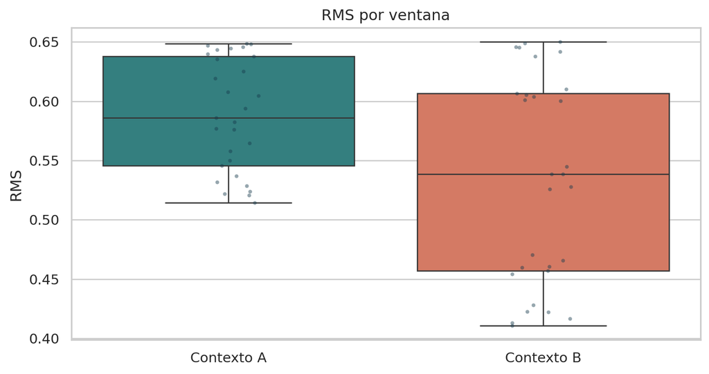

Variabilidad de RMS entre ventanas. Las ventanas describen cada registro; no son réplicas biológicas independientes.

```python
fig, ax = plt.subplots(figsize=(9, 4.5))
sns.boxplot(
    data=rasgos_ventanas, x="contexto", y="RMS", hue="contexto",
    palette=PALETA, legend=False, ax=ax
)
sns.stripplot(
    data=rasgos_ventanas, x="contexto", y="RMS",
    color="#173b4d", alpha=0.45, size=3, ax=ax
)
ax.set(xlabel="", ylabel="RMS", title="RMS por ventana")
plt.show()
```

Resuma los descriptores por ventanas usando mediana e IQR. No aplique automáticamente una prueba *t*, Mann-Whitney ni ANOVA: el solapamiento induce dependencia y las ventanas pertenecen al mismo registro.

**Mostrar/ocultar código**

```python
rasgos_ventanas.groupby("contexto")[["media", "desv_est", "RMS", "MAV"]].agg(
    ["median", lambda s: s.quantile(0.75) - s.quantile(0.25)]
).round(4)
```

| contexto | media median | media <lambda_0> | desv_est median | desv_est <lambda_0> | RMS median | RMS <lambda_0> | MAV median | MAV <lambda_0> |
| --- | --- | --- | --- | --- | --- | --- | --- | --- |
| Contexto A | 0.0024 | 0.0064 | 0.5863 | 0.0922 | 0.5860 | 0.0922 | 0.5034 | 0.084 |
| Contexto B | 0.0011 | 0.0081 | 0.5386 | 0.1494 | 0.5385 | 0.1493 | 0.4350 | 0.129 |

## 10 9. Ruta opcional: señales simultáneas o alineables

Use esta sección **solo** si ambos registros corresponden al mismo fenómeno temporal o a eventos homólogos. Una correlación baja entre registros independientes no tiene una interpretación útil.

### 10.1 9.1 Armonizar la grilla temporal

La interpolación siguiente crea una grilla común en la región de solapamiento. Si implica reducir $f_s$, debe existir filtrado antialias antes del remuestreo.

**Mostrar/ocultar código**

```python
def alinear_por_interpolacion(A, B, col_t, col_x, fs_objetivo=None):
    inicio = max(A[col_t].min(), B[col_t].min())
    fin = min(A[col_t].max(), B[col_t].max())
    if fin <= inicio:
        raise ValueError("Los registros no comparten intervalo temporal.")
    fs_a = 1 / np.median(np.diff(A[col_t]))
    fs_b = 1 / np.median(np.diff(B[col_t]))
    fs = min(fs_a, fs_b) if fs_objetivo is None else float(fs_objetivo)
    t = np.arange(inicio, fin, 1/fs)
    xa = np.interp(t, A[col_t], A[col_x])
    xb = np.interp(t, B[col_t], B[col_x])
    return t, xa, xb, fs


t_comun, x_A_comun, x_B_comun, fs_comun = alinear_por_interpolacion(
    A, B, CONFIG["columna_tiempo"], CONFIG["columna_senal"]
)
```

### 10.2 9.2 Correlación, retardo y error

El coeficiente de Pearson mide asociación lineal sin retardo. La correlación cruzada normalizada permite buscar el desfase que maximiza la similitud:

$$r_{xy}[k]=\frac{1}{N}\sum_n z_x[n]z_y[n+k].$$

**Mostrar/ocultar código**

```python
def estandarizar(x):
    x = np.asarray(x, dtype=float)
    sd = x.std(ddof=0)
    if sd == 0:
        raise ValueError("No se puede estandarizar una señal constante.")
    return (x - x.mean()) / sd


z_A = estandarizar(x_A_comun)
z_B = estandarizar(x_B_comun)
corr = signal.correlate(z_B, z_A, mode="full", method="fft") / len(z_A)
lags = signal.correlation_lags(len(z_B), len(z_A), mode="full")
k_max = lags[np.argmax(np.abs(corr))]
retardo_s = k_max / fs_comun

metricas_punto = pd.Series({
    "Pearson_sin_retardo": np.corrcoef(x_A_comun, x_B_comun)[0, 1],
    "MAE_unidades_originales": np.mean(np.abs(x_B_comun - x_A_comun)),
    "RMSE_unidades_originales": np.sqrt(np.mean((x_B_comun - x_A_comun)**2)),
    "retardo_max_abs_corr_s": retardo_s,
    "max_abs_corr_normalizada": np.max(np.abs(corr)),
})
metricas_punto.round(4)
```

```
Pearson_sin_retardo         0.0075
MAE_unidades_originales     0.6447
RMSE_unidades_originales    0.7964
retardo_max_abs_corr_s      5.8760
max_abs_corr_normalizada    0.0149
dtype: float64
```

**Mostrar/ocultar código**

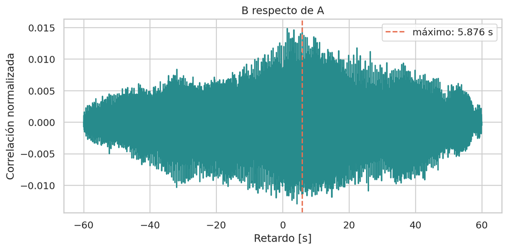

Correlación cruzada normalizada. Un máximo no demuestra causalidad.

```python
fig, ax = plt.subplots(figsize=(9, 4))
ax.plot(lags / fs_comun, corr, color="#278b8c")
ax.axvline(retardo_s, color="#e76f51", ls="--", label=f"máximo: {retardo_s:.3f} s")
ax.set(xlabel="Retardo [s]", ylabel="Correlación normalizada",
       title="B respecto de A")
ax.legend()
plt.show()
```

### 10.3 9.3 Coherencia

La coherencia estima asociación lineal por frecuencia. Requiere señales simultáneas, muestreo compatible y suficiente duración. No implica causalidad.

**Mostrar/ocultar código**

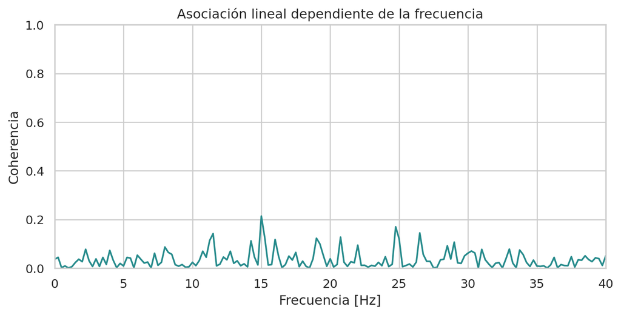

Coherencia entre señales alineadas. Interpretar solo en frecuencias con contenido y calidad suficientes.

```python
nperseg = min(len(x_A_comun), max(32, int(CONFIG["ventana_s"] * fs_comun)))
f_coh, Cxy = signal.coherence(
    x_A_comun, x_B_comun, fs=fs_comun, nperseg=nperseg,
    noverlap=int(CONFIG["solapamiento"] * nperseg)
)
fig, ax = plt.subplots(figsize=(9, 4))
ax.plot(f_coh, Cxy, color="#278b8c")
ax.set_xlim(CONFIG["frecuencia_min"], min(fmax_comun, fs_comun/2))
ax.set_ylim(0, 1)
ax.set(xlabel="Frecuencia [Hz]", ylabel="Coherencia",
       title="Asociación lineal dependiente de la frecuencia")
plt.show()
```

## 11 10. Preprocesamiento: justificar antes de aplicar

No se entrega una cadena de filtrado automática porque un filtro válido para EEG puede destruir ECG, PPG o sEMG. Proponga su cadena con esta tabla:

| Operación | Problema que corrige | Parámetros | Evidencia antes/después | Riesgo de distorsión |
| --- | --- | --- | --- | --- |
| Eliminación de tendencia |  |  |  |  |
| Filtro pasaaltas |  |  |  |  |
| Filtro pasabajas |  |  |  |  |
| Rechazo de red |  |  |  |  |
| Rectificación |  |  |  |  |
| Normalización |  |  |  |  |
| Segmentación por evento |  |  |  |  |

**PrecauciónTres errores frecuentes**

1. Filtrar porque “así se hace” sin mostrar el problema en el registro.
2. Usar `filtfilt` y describir el resultado como procesamiento en tiempo real; `filtfilt` es no causal.
3. comparar PSD calculadas con parámetros, unidades o bandas distintas.

## 12 11. Construir una conclusión defendible

La conclusión debe contener cuatro niveles claramente separados:

1. **Hallazgo:** qué descriptor cambió y cuánto cambió.
2. **Evidencia:** tabla o figura exacta que respalda el hallazgo.
3. **Interpretación:** mecanismo fisiológico compatible con el cambio.
4. **Límite:** explicación alternativa, artefacto o restricción del diseño.

Plantilla:

> En los registros analizados, **[descriptor]** fue **[valor A]** en A y **[valor B]** en B. La diferencia se observa en **[figura/tabla]** y es compatible con **[mecanismo]**. Sin embargo, **[confusor o limitación]** impide atribuir el cambio exclusivamente al contexto. Se requerirían **[réplicas, sujetos, control o anotaciones]** para evaluar la generalización.

### 12.1 Lista de control de calidad

- La pregunta y la hipótesis son explícitas.
- Los metadatos permiten reproducir la selección de señales.
- Las unidades y escalas aparecen en todos los ejes.
- La frecuencia de muestreo se verificó.
- Cada decisión de preprocesamiento tiene justificación.
- Las ventanas tienen duración y solapamiento documentados.
- La PSD usa parámetros comparables.
- Los rasgos seleccionados corresponden al tipo de señal.
- No se presentan ventanas como sujetos independientes.
- La interpretación diferencia fisiología, adquisición y artefactos.

## 13 12. Entregables

Cada grupo entregará:

1. archivo fuente `.qmd` ejecutable;
2. documento HTML autocontenido;
3. archivos o enlace verificable a los datos, respetando su licencia;
4. tabla de metadatos y decisiones de preprocesamiento;
5. máximo cinco figuras principales, cada una con mensaje e interpretación;
6. conclusión con hallazgo, evidencia, interpretación y límite;
7. sustentación de 8 minutos y 4 minutos de preguntas.

El código debe ejecutarse de principio a fin. Una figura sin unidades, una métrica sin definición o una decisión sin justificación se considera evidencia incompleta.

## 14 13. Rúbrica de evaluación

| Criterio | Excelente | Adecuado | Insuficiente | Peso |
| --- | --- | --- | --- | --- |
| Pregunta y comparabilidad | Pregunta mecanística; variables, unidades y condiciones son comparables | Pregunta clara con alguna limitación menor | Contextos o señales no son comparables | 15 % |
| Auditoría y reproducibilidad | Metadatos completos; carga, limpieza y decisiones reproducibles | Flujo ejecutable con documentación parcial | Cambios manuales, datos opacos o errores de ejecución | 15 % |
| EDA temporal | Describe forma, distribución, artefactos y variación local con interpretación | Incluye descriptores y gráficos básicos correctos | Enumera métricas sin relacionarlas con la señal | 15 % |
| EDA espectral | Welch, bandas, resolución y unidades están justificadas | PSD correcta con justificación parcial | FFT/PSD mal escalada o interpretación de picos sin soporte | 15 % |
| Comparación e interpretación biomédica | Integra magnitud, variabilidad, fisiología, adquisición y límites | Compara correctamente, pero integra parcialmente los mecanismos | Confunde correlación, diferencia e inferencia causal/clínica | 25 % |
| Comunicación y sustentación | Figuras legibles; argumentos precisos; todos dominan el método | Presentación comprensible con vacíos menores | Resultados no defendibles o participación desigual | 15 % |

## 15 14. Preguntas para la sustentación

1. ¿Qué condición haría inválida la comparación de amplitudes?
2. ¿Por qué eligieron esa duración de ventana?
3. ¿Qué diferencia existe entre comparar registros y comparar sujetos?
4. ¿Cómo verificaron que un pico espectral no fuera interferencia o artefacto?
5. ¿Qué información se pierde al normalizar cada señal por separado?
6. ¿Qué resultado contradijo o debilitó su hipótesis inicial?
7. ¿Qué dato adicional cambiaría más su interpretación?

## 16 Referencias

- Semmlow, J. L. (2018). *Circuits, Signals, and Systems for Bioengineers: A MATLAB-Based Introduction* (3.ª ed.). Academic Press. Cap. 1: panorama y bioseñales; cap. 2: mediciones temporales y correlación; cap. 3: análisis frecuencial; cap. 10: estacionariedad y no estacionariedad. [DOI del capítulo 2](https://doi.org/10.1016/B978-0-12-809395-5.00002-3) y [DOI del capítulo 3](https://doi.org/10.1016/B978-0-12-809395-5.00003-5).
- Programa de Ingeniería Biomédica. *Sistemas y Señales Biomédicos SYSB: Programa de la asignatura*. Apartados “Temas”, “Resultados de aprendizaje esperados” y “Programación de actividades por sesión”.

**NotaCierre**

Una comparación técnicamente sólida no consiste en acumular métricas. Consiste en demostrar que los registros son comparables, seleccionar descriptores ligados a una pregunta fisiológica y reconocer qué conclusiones permite —y cuáles no permite— el diseño disponible.